# Caso practico Daniel González Millán

Este es el último caso práctico de este módulo. Para realizarlo, ha de escogerse una BBDD para realizar una exploración estadística propia de un científico de datos. Para ello, se pueden seguir los siguientes pasos para desarrollar el proyecto:

1. Definir un solo objetivo para el estudio con una BBDD. En este paso, se va a definir un objetivo de estudio (es muy importante que solo sea uno). Se definirá siguiendo estos puntos:
- ¿Qué problema se quiere solucionar con estos datos?
- ¿Qué significan las variables?
- ¿Qué tipo de variables hay?
- Definir un objetivo que ayude a solucionar el problema.

El objeto de estudio será comprobar que el valor de los premios en las competiciones en los e-sports ha ido aumentando con los años y ver si está relacionada directamente con el número de torneos y el número de jugadores.

Antes de hacer cualquier cosa, vamos a cargar el CSV, así como una serie de librerías para poder examinar el dataframe.

```r
library(DataExplorer)
library(summarytools)
library(visdat)
library(dplyr)
```

```r
library(tidyr)
library(ggplot2)
```

```r
datos <- read.csv("HistoricalEsportData.csv", header = TRUE, sep = ",")
```

```r
class(datos)
```

```
## [1] "data.frame"
```

Como vemos, lo que tenemos es un DataFrame, por ello, vamos a usar la función dfSummary, para obtener un resúmen de todas las variables de los datos.

```r
print(dfSummary(datos), method = "render")
```

Data Frame Summary

datos

**Dimensions**: 7341 x 5  
**Duplicates**: 0

| **No** | **Variable** | **Stats / Values** | **Freqs (% of Valid)** | **Graph** | **Valid** | **Missing** |
| --- | --- | --- | --- | --- | --- | --- |
| 1 | Date [character] | 1. 2020-06-01 2. 2019-08-01 3. 2019-05-01 4. 2021-02-01 5. 2019-07-01 6. 2020-08-01 7. 2019-09-01 8. 2018-09-01 9. 2019-06-01 10. 2019-10-01 [ 265 others ] | 117 ( 1.6% ) 95 ( 1.3% ) 84 ( 1.1% ) 81 ( 1.1% ) 80 ( 1.1% ) 80 ( 1.1% ) 77 ( 1.0% ) 75 ( 1.0% ) 74 ( 1.0% ) 73 ( 1.0% ) 6505 ( 88.6% ) |  | 7341 (100.0%) | 0 (0.0%) |
| 2 | Game [character] | 1. StarCraft: Brood War 2. WarCraft III 3. Super Smash Bros. Melee 4. Age of Empires II 5. StarCraft II 6. Counter-Strike 7. League of Legends 8. Dota 2 9. Counter-Strike: Global Of 10. Team Fortress … | 220 ( 3.0% ) 198 ( 2.7% ) 195 ( 2.7% ) 182 ( 2.5% ) 143 ( 1.9% ) 140 ( 1.9% ) 136 ( 1.9% ) 124 ( 1.7% ) 115 ( 1.6% ) 101 ( 1.4% ) 5787 ( 78.8% ) |  | 7341 (100.0%) | 0 (0.0%) |
| 3 | Earnings [numeric] | Mean (sd) : 156036.1 (1026844) min ≤ med ≤ max: 0 ≤ 8818 ≤ 40125697 IQR (CV) : 55570 (6.6) | 5013 distinct values |  | 7341 (100.0%) | 0 (0.0%) |
| 4 | Players [integer] | Mean (sd) : 53.3 (120.9) min ≤ med ≤ max: 0 ≤ 15 ≤ 1709 IQR (CV) : 39 (2.3) | 475 distinct values |  | 7341 (100.0%) | 0 (0.0%) |
| 5 | Tournaments [integer] | Mean (sd) : 6.5 (12.2) min ≤ med ≤ max: 1 ≤ 2 ≤ 172 IQR (CV) : 5 (1.9) | 100 distinct values |  | 7341 (100.0%) | 0 (0.0%) |

Generated by summarytools 1.0.1 ([R](https://www.r-project.org/) version 4.1.1)  
2022-07-28

Como podemos observar, tenemos 5 variables distintas: dos de tipo “Character”, que son la fecha y el nombre del juego, uno de tipo numérico, que son los ingresos y por último, dos de tipo “integer”, que son el número de jugadores y el número de torneos. Otra cosa que podemos observar para las variables integer y numéricas es que no siguen distribuciones simétricas, tienen más valores a la izquierda de la distribución que a la derecha.

```r
freq(datos$Date)
```

```
## Frequencies
## datos$Date
## Type: Character
##
##                    Freq   % Valid   % Valid Cum.   % Total   % Total Cum.
## ---------------- ------ --------- -------------- --------- --------------
##       1998-01-01      1     0.014          0.014     0.014          0.014
##       1998-05-01      1     0.014          0.027     0.014          0.027
##       1998-07-01      2     0.027          0.054     0.027          0.054
##       1998-11-01      3     0.041          0.095     0.041          0.095
##       1998-12-01      1     0.014          0.109     0.014          0.109
##       1999-03-01      1     0.014          0.123     0.014          0.123
##       1999-04-01      1     0.014          0.136     0.014          0.136
##       1999-05-01      2     0.027          0.163     0.027          0.163
##       1999-08-01      2     0.027          0.191     0.027          0.191
##       1999-09-01      2     0.027          0.218     0.027          0.218
##       1999-10-01      1     0.014          0.232     0.014          0.232
##       1999-12-01      1     0.014          0.245     0.014          0.245
##       2000-01-01      2     0.027          0.272     0.027          0.272
##       2000-02-01      2     0.027          0.300     0.027          0.300
##       2000-04-01      3     0.041          0.341     0.041          0.341
##       2000-05-01      3     0.041          0.381     0.041          0.381
##       2000-06-01      3     0.041          0.422     0.041          0.422
##       2000-07-01      6     0.082          0.504     0.082          0.504
##       2000-08-01      3     0.041          0.545     0.041          0.545
##       2000-09-01      3     0.041          0.586     0.041          0.586
##       2000-10-01      5     0.068          0.654     0.068          0.654
##       2000-11-01      1     0.014          0.667     0.014          0.667
##       2000-12-01      3     0.041          0.708     0.041          0.708
##       2001-01-01      4     0.054          0.763     0.054          0.763
##       2001-02-01      1     0.014          0.776     0.014          0.776
##       2001-03-01      1     0.014          0.790     0.014          0.790
##       2001-04-01      3     0.041          0.831     0.041          0.831
##       2001-05-01      4     0.054          0.885     0.054          0.885
##       2001-06-01      1     0.014          0.899     0.014          0.899
##       2001-07-01      2     0.027          0.926     0.027          0.926
##       2001-08-01      7     0.095          1.022     0.095          1.022
##       2001-09-01      2     0.027          1.049     0.027          1.049
##       2001-10-01      2     0.027          1.076     0.027          1.076
##       2001-11-01      3     0.041          1.117     0.041          1.117
```

[output cut: 228 more lines]

```
##       2020-12-01     55     0.749         90.846     0.749         90.846
##       2021-01-01     59     0.804         91.650     0.804         91.650
##       2021-02-01     81     1.103         92.753     1.103         92.753
##       2021-03-01     58     0.790         93.543     0.790         93.543
##       2021-04-01     60     0.817         94.360     0.817         94.360
##       2021-05-01     57     0.776         95.137     0.776         95.137
##       2021-06-01     56     0.763         95.900     0.763         95.900
##       2021-07-01     48     0.654         96.554     0.654         96.554
##       2021-08-01     49     0.667         97.221     0.667         97.221
##       2021-09-01     44     0.599         97.820     0.599         97.820
##       2021-10-01     61     0.831         98.651     0.831         98.651
##       2021-11-01     53     0.722         99.373     0.722         99.373
##       2021-12-01     46     0.627        100.000     0.627        100.000
##             <NA>      0                              0.000        100.000
##            Total   7341   100.000        100.000   100.000        100.000
```

Una primera impresión que sacamos a primera vista, observando las fechas, es que cada año se han ido realizando más torneos de videojuegos, lo que nos puede dar una primera pista sobre si el dinero invertido en torneos se ha ido aumentando con los años o no.

2. Exploración de datos:
- Crear los gráficos más apropiados.
- Interpretar los gráficos.
- Encontrar los primeros indicios y sacar las preconclusiones.
- Listar por orden de importancia los indicios que han desvelado los gráficos.

```r
datos$Date <- substr(datos$Date, start = 0, stop = 4)
```

```r
datos
```

| Date | Game | Earnings | Players | Tournaments |
| --- | --- | --- | --- | --- |
| 1998 | QuakeWorld | 15000.00 | 8 | 1 |
| 1998 | Quake II | 14600.00 | 4 | 1 |
| 1998 | Quake II | 15000.00 | 5 | 1 |
| 1998 | QuakeWorld | 6500.00 | 4 | 1 |
| 1998 | Quake II | 36600.00 | 13 | 2 |
| 1998 | QuakeWorld | 22000.00 | 0 | 1 |
| 1998 | StarCraft: Brood War | 20000.00 | 8 | 1 |
| 1998 | Age of Empires | 2000.00 | 1 | 1 |
| 1999 | Quake II | 15000.00 | 5 | 1 |
| 1999 | StarCraft: Brood War | 3000.00 | 2 | 1 |

[output cut: 7331 more lines]

```r
datos$Date_numeric <- as.numeric(datos$Date)
```

```r
datos_agrupados <- group_by(datos, Date_numeric)
```

```r
datos_agrupados
```

| Date | Game | Earnings | Players | Tournaments | Date_numeric |
| --- | --- | --- | --- | --- | --- |
| 1998 | QuakeWorld | 15000.00 | 8 | 1 | 1998 |
| 1998 | Quake II | 14600.00 | 4 | 1 | 1998 |
| 1998 | Quake II | 15000.00 | 5 | 1 | 1998 |
| 1998 | QuakeWorld | 6500.00 | 4 | 1 | 1998 |
| 1998 | Quake II | 36600.00 | 13 | 2 | 1998 |
| 1998 | QuakeWorld | 22000.00 | 0 | 1 | 1998 |
| 1998 | StarCraft: Brood War | 20000.00 | 8 | 1 | 1998 |
| 1998 | Age of Empires | 2000.00 | 1 | 1 | 1998 |
| 1999 | Quake II | 15000.00 | 5 | 1 | 1999 |
| 1999 | StarCraft: Brood War | 3000.00 | 2 | 1 | 1999 |

[output cut: 7331 more lines]

Como lo que nos interesa son los datos en global, no por videojuegos y, teniendo en cuenta que los datos están puestos por meses, vamos a agrupar los datos por años para hacer nuestros estudios.

```r
datos_agrup_mes <- summarise(datos_agrupados, "Earnings" = sum(Earnings), "Players" = sum(Players), "Number_of_Tournaments" = sum(Tournaments))
```

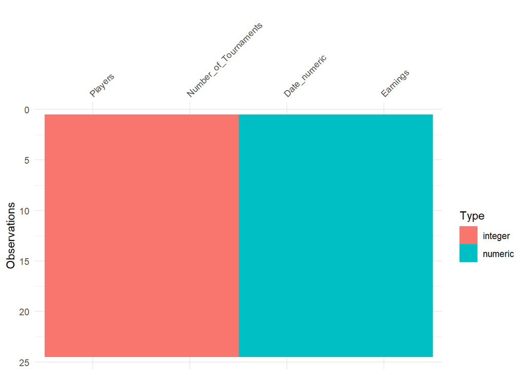

```r
vis_dat(datos_agrup_mes)
```

```r
datos_agrup_mes
```

| Date_numeric | Earnings | Players | Number_of_Tournaments |
| --- | --- | --- | --- |
| 1998 | 131700.0 | 43 | 9 |
| 1999 | 275153.8 | 82 | 16 |
| 2000 | 745307.5 | 347 | 64 |
| 2001 | 893764.5 | 574 | 63 |
| 2002 | 1268219.6 | 793 | 80 |
| 2003 | 1784460.1 | 1502 | 187 |
| 2004 | 2849828.6 | 2491 | 270 |
| 2005 | 4311856.9 | 2936 | 330 |
| 2006 | 5657830.3 | 3870 | 406 |
| 2007 | 7460049.5 | 4535 | 505 |

[output cut: 14 more lines]

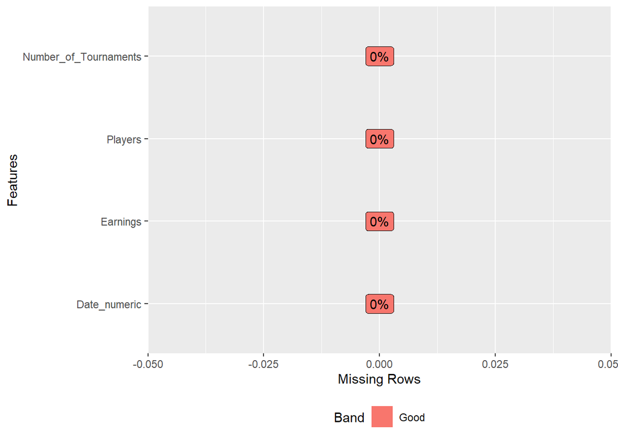

```r
plot_missing(datos_agrup_mes)
```

Como podemos observar, no hay missings para ninguna de las variables que vamos a estudiar. Por lo que nuestros datos están preparados para poder ser estudiados.

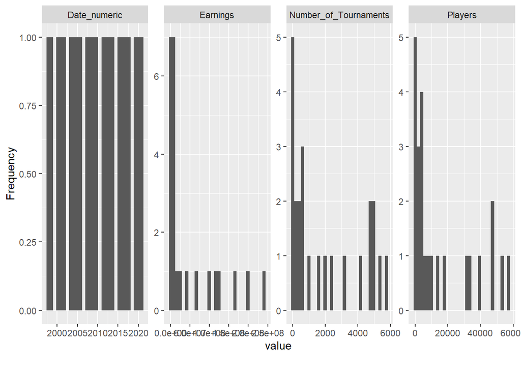

```r
plot_histogram(datos_agrup_mes)
```

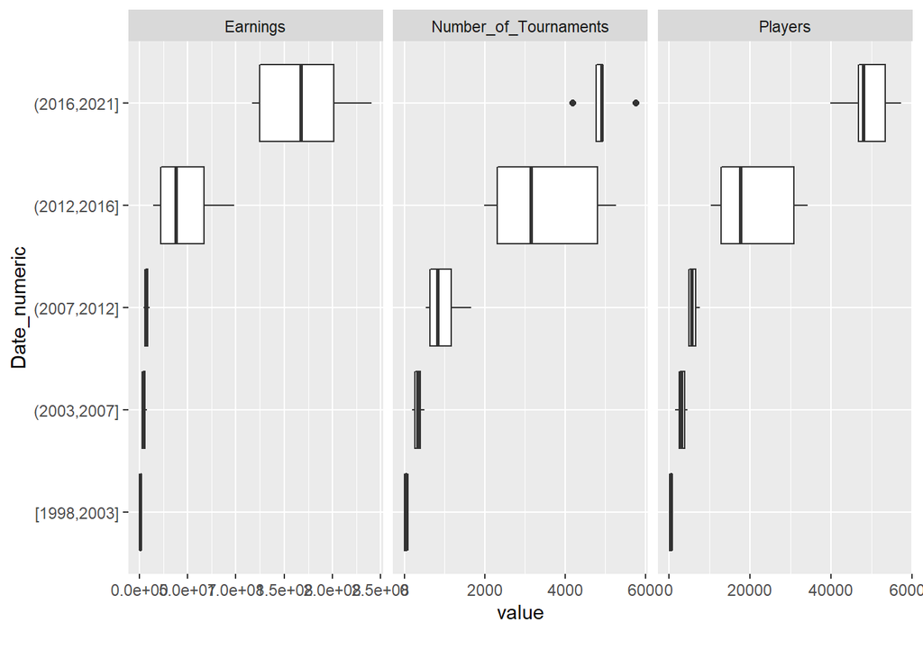

```r
plot_boxplot(datos_agrup_mes, by="Date_numeric")
```

Parece que, conforme aumenta la variable año, aumenta el número de torneos, así como el número de jugadores y, por lo tanto, el dinero destinado a premios. Esto se puede observar más concreatamente con la matriz de correlación.

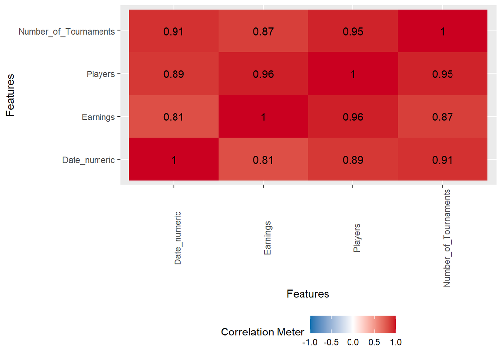

```r
plot_correlation(datos_agrup_mes)
```

Las variable de cantidad de jugadores y cantidad de torneos están muy relacionadas, lo cual, a priori, era lógico, ya que a mayor número de torneos que tengamos, más personas tendríamos que tener jugando torneos.

No obstante, para nuestro estudio nos enfocaremos en dos puntos: - La cantidad de dinero ganado con respecto al tiempo (creemos que deberá ser creciente). - La cantidad de dinero ganados respecto a la cantidad de jugadores y de torneos (igualmente deberá ser creciente y podría ser la explicación de por qué cada vez see gana más dinero en los e-sports)

3. Ahora es momento de decidir si las preconclusiones son ciertas o no. Apoyarse en la estadística inferencial y del diseño de experimentos.
- Encontrar las técnicas más apropiadas para corroborar las preconclusiones con la ayuda de un mapa.
- Diseñar la metodología de análisis.
- Aplicar esta metodología.
- Resumir los resultados.

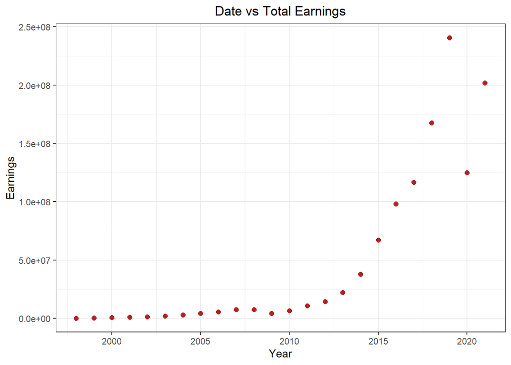

```r
ggplot(data = datos_agrup_mes, mapping = aes(x = Date_numeric, y = Earnings)) +
  geom_point(color = "firebrick", size = 2) +
  labs(title  =  'Date vs Total Earnings', x  =  'Year') +
  theme_bw() +
  theme(plot.title = element_text(hjust = 0.5))
```

```r
cor.test(x = datos_agrup_mes$Date_numeric, y = datos_agrup_mes$Earnings, method = "pearson")
```

```
##
##  Pearson's product-moment correlation
##
## data:  datos_agrup_mes$Date_numeric and datos_agrup_mes$Earnings
## t = 6.4171, df = 22, p-value = 1.861e-06
## alternative hypothesis: true correlation is not equal to 0
## 95 percent confidence interval:
##  0.5990213 0.9132921
## sample estimates:
##       cor
## 0.8073318
```

```r
modelo <- lm(Earnings ~ Date_numeric, datos_agrup_mes)
summary(modelo)
```

```
##
## Call:
## lm(formula = Earnings ~ Date_numeric, data = datos_agrup_mes)
##
## Residuals:
##       Min        1Q    Median        3Q       Max
## -54067648 -30758142  -4664093  24666244 115329460
##
## Coefficients:
##                Estimate Std. Error t value Pr(>|t|)
## (Intercept)  -1.638e+10  2.560e+09  -6.398 1.94e-06 ***
## Date_numeric  8.176e+06  1.274e+06   6.417 1.86e-06 ***
## ---
## Signif. codes:  0 '***' 0.001 '**' 0.01 '*' 0.05 '.' 0.1 ' ' 1
##
## Residual standard error: 43200000 on 22 degrees of freedom
## Multiple R-squared:  0.6518, Adjusted R-squared:  0.636
## F-statistic: 41.18 on 1 and 22 DF,  p-value: 1.861e-06
```

Por lo que podemos concluir que, con la evolución en los años, las ganancias por torneos en los e-sports ha ido aumentando. Podemos aprovechar las otras dos variables que tenemos para ahondar un poco mas en las conclusiones, ya que parece lógico que se hayan producido más ganancias por el creciente número de jugadores y torneos. Por ello, vamos a comprar el número de jugadores y el número de torneos con las ganancias:

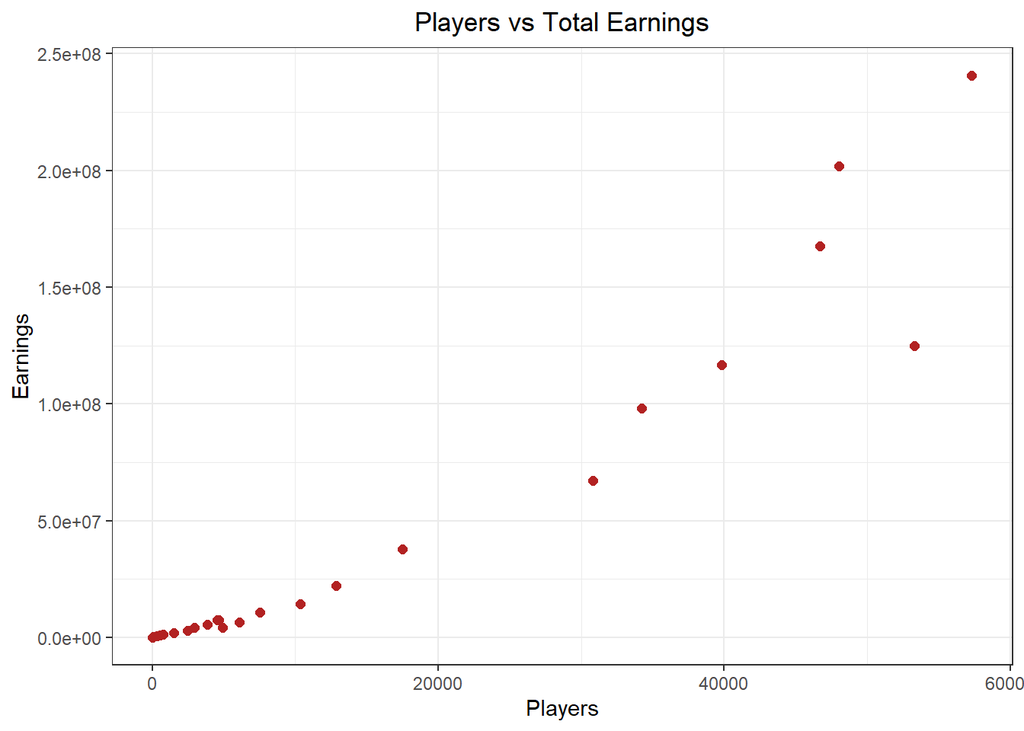

```r
ggplot(data = datos_agrup_mes, mapping = aes(x = Players, y = Earnings)) +
  geom_point(color = "firebrick", size = 2) +
  labs(title  =  'Players vs Total Earnings', x  =  'Players') +
  theme_bw() +
  theme(plot.title = element_text(hjust = 0.5))
```

```r
cor.test(x = datos_agrup_mes$Players, y = datos_agrup_mes$Earnings, method = "pearson")
```

```
##
##  Pearson's product-moment correlation
##
## data:  datos_agrup_mes$Players and datos_agrup_mes$Earnings
## t = 15.75, df = 22, p-value = 1.834e-13
## alternative hypothesis: true correlation is not equal to 0
## 95 percent confidence interval:
##  0.9048239 0.9821018
## sample estimates:
##       cor
## 0.9584013
```

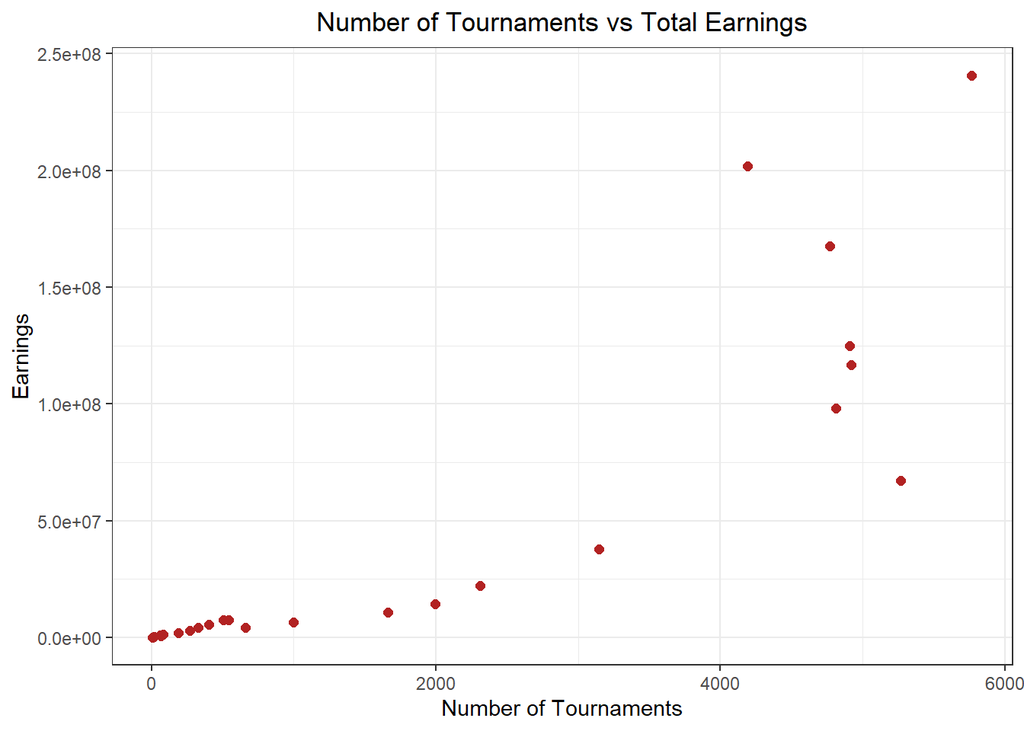

```r
ggplot(data = datos_agrup_mes, mapping = aes(x = Number_of_Tournaments, y = Earnings)) +
  geom_point(color = "firebrick", size = 2) +
  labs(title  =  'Number of Tournaments vs Total Earnings', x  =  'Number of Tournaments') +
  theme_bw() +
  theme(plot.title = element_text(hjust = 0.5))
```

```r
cor.test(x = datos_agrup_mes$Number_of_Tournaments, y = datos_agrup_mes$Earnings, method = "pearson")
```

```
##
##  Pearson's product-moment correlation
##
## data:  datos_agrup_mes$Number_of_Tournaments and datos_agrup_mes$Earnings
## t = 8.1465, df = 22, p-value = 4.362e-08
## alternative hypothesis: true correlation is not equal to 0
## 95 percent confidence interval:
##  0.7122067 0.9410384
## sample estimates:
##       cor
## 0.8666215
```